# Study B: Exploring massive CITE-seq data from 161k PBMCs with scBubbletree

SK

This vignette introduces `scBubbletree`, a transparent workflow for exploration of single cell RNA-seq data. To run this vignette we need a few R-packages:

```r
library(scBubbletree)
library(Seurat)
library(ggrepel)
library(SeuratDisk)
```

## Data

In this case study we will analyze a scRNA-seq dataset of 161,764 cells peripheral blood mononuclear cells (PBMCs) from eight healthy volunteers enrolled in an HIV vaccine trial[^1]. Analysis of this data based on Seurat is presented here[^2]

Sample collection and data processing details are provided in the respective publication. In the following we summarize the key workflow steps. Key data collection and processing steps are summarized in the following. Samples were collected at three time points: immediately before (day 0), 3 days, and 7 days following administration of a HIV vaccine. All samples were profiled using 10x Chromium 3’ protocol, followed by Illumina NovaSeq 6000 sequencing. Alongside the single cell transcriptomes, CITE-seq technology was used with up to 228 antibodies to profile cell-surface protein expression.

```r
# create directory
dir.create(path = "case_study_B/")


# 1. download reference data from vignette:
https://atlas.fredhutch.org/data/nygc/multimodal/pbmc_multimodal.h5seurat


# 2. load SeuratDisk
d <- LoadH5Seurat("case_study_B/pbmc_multimodal.h5seurat")
save(d, file = "case_study_B/Hao_2021.RData")


# 3. remove precomputed reductions
d <- get(load(file = "case_study_B/Hao_2021.RData"))
d[["mt"]] <- PercentageFeatureSet(d, pattern = "^MT-")
d@reductions$apca <- NULL
d@reductions$aumap <- NULL
d@reductions$spca <- NULL
d@reductions$wnn.umap <- NULL
d@reductions$umap <- NULL


# 4. run UMAP and t-SNE again
d <- RunUMAP(object = d, dims = 1:15, reduction = "pca")
d <- RunTSNE(object = d, dims = 1:15, reduction = "pca")
save(d, file = "case_study_B/Hao_2021.RData")
```

Lets look at the number of cells per donor at a given sampling time:

```r
table(d@meta.data$time, d@meta.data$donor)
```

```
FALSE
FALSE       P1   P2   P3   P4   P5   P6   P7   P8
FALSE   0 6443 5978 4698 5307 7020 6093 8909 8916
FALSE   3 5917 5714 5002 5793 6933 7583 8200 9203
FALSE   7 5775 5513 4960 5990 7858 7066 8762 8131
```

We can show the number of cells per donor and predicted cell type from annotation set *l1*

```r
table(d@meta.data$celltype.l1, d@meta.data$donor)
```

```
FALSE
FALSE             P1   P2   P3   P4   P5   P6   P7   P8
FALSE   B        715 1335  925 1296 1798 3229 3472 1030
FALSE   CD4 T   6500 5717 4721 5103 2925 4457 5429 6149
FALSE   CD8 T   3233 3497 1623 3049 3605 1503 3232 5727
FALSE   DC       334  276  250  333  668  379  904  445
FALSE   Mono    5036 3500 4088 5188 8022 6627 9196 7353
FALSE   NK      1590 1610 2423  688 2760 3357 2303 3933
FALSE   other    491  210  180  154  952  506  576  373
FALSE   other T  236 1060  450 1279 1081  684  759 1240
```

… and also from annotation set *l2*

```r
table(d@meta.data$celltype.l2,
      d@meta.data$donor)
```

```
FALSE
FALSE                       P1   P2   P3   P4   P5   P6   P7   P8
FALSE   ASDC                 9    6    4    8   14    9   22    4
FALSE   B intermediate      81  167  209  197  327  447  667  336
FALSE   B memory           124  133  132  410  379  665 1009  433
FALSE   B naive            448  958  571  650 1071 2092 1693  235
FALSE   CD14 Mono         4252 2769 3321 4730 7163 5571 8287 6597
FALSE   CD16 Mono          784  731  767  458  859 1056  909  756
FALSE   CD4 CTL            509  262    5   10   35    4  514  397
FALSE   CD4 Naive         2498 2998 1646 1907 1377 1520 2441 3092
FALSE   CD4 Proliferating   21   15   13   12    7   11   22    7
FALSE   CD4 TCM           2421 1523 2114 2260 1050 2225 1722 1574
FALSE   CD4 TEM            481  225  701  528  380  629  490  848
FALSE   CD8 Naive         1246 2236  710 1802 1360  622 1229 1563
FALSE   CD8 Proliferating   16    6    2    4   16    9   21   17
FALSE   CD8 TCM            384  229  213  765  228  389  227  448
FALSE   CD8 TEM           1587 1026  698  478 2001  483 1755 3699
FALSE   cDC1                21    8    8   27   26    9   47    5
FALSE   cDC2               247  216  160  258  447  284  519  370
FALSE   dnT                 64  129   27   42    7   10   40   37
FALSE   Doublet            101   90   77   38  124   89   44   42
FALSE   Eryth               24   13   11   13    4    6    4    8
FALSE   gdT                129  696   50  189  848  239  438 1060
FALSE   HSPC               222   19   20   29    7    8   10   14
FALSE   ILC                  5   27   14    5   30   27   17    7
FALSE   MAIT                43  235  373 1048  226  435  281  143
FALSE   NK                1417 1442 2258  641 2540 3006 2177 3692
FALSE   NK Proliferating    77   49   65   32  126   68   50   81
FALSE   NK_CD56bright       96  119  100   15   94  283   76  160
FALSE   pDC                 57   46   78   40  181   77  316   66
FALSE   Plasmablast         62   77   13   39   21   25  103   26
FALSE   Platelet           139   61   58   69  787  376  501  302
FALSE   Treg               570  694  242  386   76   68  240  231
```

How many distinct *cell types* are there in each annotation set?

```r
length(unique(d@meta.data$celltype.l1))
```

```
FALSE [1] 8
```

```r
length(unique(d@meta.data$celltype.l2))
```

```
FALSE [1] 31
```

## scBubbletree inputs

We will analyze this data with `scBubbletree`.

As first input `scBubbletree` uses matrix $A^{n\times f}$ which represents a low-dimensional projection of the original scRNA-seq data, with $n$ rows as cells and $f$ columns as low-dimension features.

We will use the PCA projection generated by `Seurat` as $A$. In particular, we will use the first 15 principal components (PCs) as each additional PC appears to explain negligible amount of variance in the data.

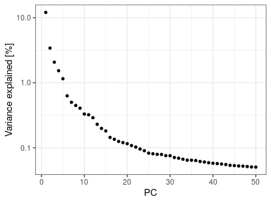

```r
var_explained <- ((d[["pca"]]@stdev)^2)/d[["pca"]]@misc$total.variance

g_var_explained <- ggplot(data = data.frame(var_explained = var_explained*100,
                                            PC = 1:length(var_explained)))+
  geom_point(aes(y = var_explained, x = PC), size = 1)+
  ylab(label = "Variance explained [%]")+
  scale_y_log10()

g_var_explained
```

Subset the 15 first PCs

```r
# This is the main input of scBubbletree -> matrix A
A <- d@reductions$pca@cell.embeddings[, 1:15]
```

```r
# A has n=cells as rows, f=features as columns (e.g. from PCA)
dim(A)
```

```
FALSE [1] 161764     15
```

We also need the meta data which includes information for each cell, such as cell ID, sample/subject name, cell type prediction labels and 2D t-SNE and UMAP coordinates

```r
# meta data
meta <- d@meta.data
meta$tSNE_1 <- d@reductions$tsne@cell.embeddings[, 1]
meta$tSNE_2 <- d@reductions$tsne@cell.embeddings[, 2]
meta$UMAP_1 <- d@reductions$umap@cell.embeddings[, 1]
meta$UMAP_2 <- d@reductions$umap@cell.embeddings[, 2]
```

We will also need the expressions of some key PBMC markers for some of the downstream analyses

```r
# quantitative features (gene expressions of marker genes) to be used later on:
# * GNLY, NKG7: NK cells
# * IL7R:   CD4 T cells
# * CD8A:   CD8 T cells
# * MS4A1:  B cells
# * CD14, LYZ:  CD14+ Monocytes
# * FCGR3A, MS4A7:  FCGR3A+ Monocytes
# * FCER1A, CST3:   Dendritic Cells
# * PPBP:   Megakaryocytes
as <- t(as.matrix(d@assays$SCT@data[
  rownames(d@assays$SCT@data) %in%
    c("IL7R",
      "CD14", "LYZ",
      "MS4A1",
      "CD8A",
      "GNLY", "NKG7",
      "FCGR3A", "MS4A7",
      "FCER1A", "CST3",
      "PPBP"), ]))
```

## scBubbletree algorithm

The `scBubbletree` workflow performs the following steps:

1. determine the clustering resolution (number of clusters $k$ or resolution $r$)
2. clustering with $k$-means or Louvain
3. hierarchical organization of clusters (bubbles)
4. visualization

### 1. determine the clustering resolution

If we intend to use the k-means clustering algorithm we first need to find an appropriate value of the number of clusters $k$. Alternatively, we can the Louvain algorithm for clustering, in which case we need to find an appropriate value for the resolution parameter $r$.

#### 1.1 determining the number of clusters $k$

How many clusters (cell types) are there are in the data? Can we guess a reasonable value of $k$?

We can study the literature or databases such as the human protein atlas database (HPA) to identify a range of reasonable $k$s. HPA provides a decomposition of PBMCs into 18 canonical cell populations[^3]. Given that here we have about 162k PBMCs we might be able to recover all 18 subtypes, and hence $k\approx18$ seems as a reasonable first choice.

We can also use the function `get_k` for data-driven estimation of $k$ based on the Gap statistic and the within-cluster sum of squares (WCSS).

Lets run `get_k` now

```r
b_k <- get_k(ks = c(seq(from = 1, to = 50, by = 1), 51, 56, 72, 82, 97, 111),
             x = A,
             n_start = 100,
             iter_max = 200,
             kmeans_algorithm = "MacQueen",
             cores = 60,
             B_gap = 20)
```

The Gap statistic curve and the WCSS curve appear to follow three general regimes. In the first regime we see a steep increase in the Gap statistic and a steep decrease in WCSS for values of $k$ between 1 and 6 (approximately the number of major PBMC subtypes).

Second, between $k\approx7$ and $k\approx16$ both curves follow similar trends as before but have smaller slopes, i.e. the change in the Gap statistic and WCSS as a function of $k$ is smaller in the second regime.

Third, both curves level off around $k\approx16$, and incremental increase in $k$ beyond this point results in negligible changes in either metric.

In summary, the Gap statistic and WCSS curves are consistent with our prior knowledge about PBMCs, i.e. at $k\approx16$ most of the canonical PBMC cell populations are likely to have been recovered, and there appears to be little benefit in using larger values of $k$.

```r
g0_k <- ggplot(data = b_k$gap_stats_summary)+
  geom_point(aes(x = k, y = gap_mean), size = 1)+
  geom_errorbar(aes(x = k, y = gap_mean, ymin = L95, ymax = H95), width = 0.1)+
  ylab(label = "Gap")|
ggplot(data = b_k$wcss_stats_summary)+
  geom_point(aes(x = k, y = wcss_mean), size = 1)+
  ylab(label = "WCSS")+
  scale_y_log10()+
  annotation_logticks(base = 10, sides = "l")
```

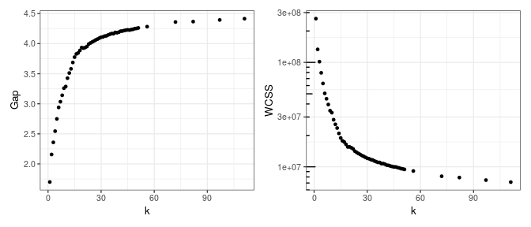

```r
g0_k
```

#### 1.2 determining the resolution parameter $r$

For Louvain clustering we need to select a clustering resolution $r$. Higher resolutions lead to more communities and lower resolutions lead to fewer communities. We can use the same strategy as before to find a reasonable value of $r$.

Lets use the function `get_r` for data-driven estimation of $r$ based on the Gap statistic and WCSS. As input we need to provide the matrix $A$ and a vector of $r$s. As output we will get Gap statistic and WCSS estimates for each $r$ (or the number of communities $k$ detected at each resolution $r$).

```r
b_r <- get_r(B_gap = 20,
             rs = 10^seq(from = -4, to = 1, by = 0.1),
             x = A,
             n_start = 20,
             iter_max = 100,
             louvain_algorithm = "original",
             cores = 10)
```

```r
g0_r <- ggplot(data = b_r$gap_stats_summary)+
  geom_point(aes(x = k, y = gap_mean), size = 1)+
  geom_point(data = b_r$gap_stats_summary[b_r$gap_stats_summary$k == 24,],
             aes(x = k, y = gap_mean), size = 3, shape = 21, col = "red")+
  geom_errorbar(aes(x = k, y = gap_mean, ymin = L95, ymax = H95), width = 0.1)+
  ylab(label = "Gap")|
ggplot(data = b_r$wcss_stats_summary)+
  geom_point(aes(x = k, y = wcss_mean), size = 1)+
  geom_point(data = b_r$wcss_stats_summary[b_r$wcss_stats_summary$k == 24,],
             aes(x = k, y = wcss_mean), size = 3, shape = 21, col = "red")+
  ylab(label = "WCSS")+
  scale_y_log10()+
  annotation_logticks(base = 10, sides = "l")
```

We see a soft elbow at $k\approx24$ (red hollow points) in the Gap statistic and WCSS curves. In fact, the $\Delta$ in the Gap statistic between $k=22$ and $k=24$ is roughly equal to the $\Delta$ between $k=24$ and $k=72$. Means (points) and 95% confidence intervals are shown for the Gap statistic at each $k$ computed using `B_gap`=20 MCMC simulations.

In summary, the Louvain algorithm suggests slightly higher $k$ than k-means. We get $k=24$ with resolution parameter $r\approx0.79$, which is the default setting of $r$ used by the Seurat R-package.

Importantly, the final choice of $k$ also depends on the intent of the researcher and on the design of the experiment. Given that dataset B was generated at high throughput and consists of over 161,000 cells, we decided to use $k=24$ for the clustering step as this would enable us to recover the canonical PBMC subtypes.

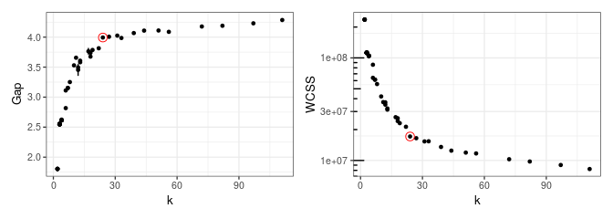

```r
g0_r
```

Table with Gap statistic estimates and ($k$, $r$) pairs:

| gap_mean | r | k | gap_SE | L95 | H95 |
| --- | --- | --- | --- | --- | --- |
| 1.804 | 0.000 | 2 | 0.001 | 1.802 | 1.805 |
| 1.804 | 0.000 | 2 | 0.001 | 1.803 | 1.806 |
| 1.804 | 0.000 | 2 | 0.001 | 1.803 | 1.805 |
| 1.804 | 0.000 | 2 | 0.001 | 1.802 | 1.805 |
| 2.549 | 0.000 | 3 | 0.001 | 2.547 | 2.550 |
| 2.549 | 0.000 | 3 | 0.001 | 2.547 | 2.550 |
| 2.549 | 0.000 | 3 | 0.001 | 2.547 | 2.550 |
| 2.549 | 0.001 | 3 | 0.001 | 2.547 | 2.551 |
| 2.549 | 0.001 | 3 | 0.001 | 2.547 | 2.551 |
| 2.549 | 0.001 | 3 | 0.001 | 2.547 | 2.551 |
| 2.549 | 0.001 | 3 | 0.001 | 2.548 | 2.550 |
| 2.549 | 0.001 | 3 | 0.001 | 2.547 | 2.550 |
| 2.549 | 0.002 | 3 | 0.001 | 2.546 | 2.551 |
| 2.549 | 0.002 | 3 | 0.001 | 2.547 | 2.550 |
| 2.548 | 0.003 | 3 | 0.001 | 2.547 | 2.550 |
| 2.549 | 0.003 | 3 | 0.001 | 2.547 | 2.551 |
| 2.557 | 0.004 | 3 | 0.001 | 2.555 | 2.558 |
| 2.616 | 0.005 | 4 | 0.001 | 2.614 | 2.618 |
| 2.614 | 0.006 | 4 | 0.001 | 2.613 | 2.615 |
| 2.625 | 0.008 | 4 | 0.001 | 2.624 | 2.626 |
| 2.614 | 0.010 | 4 | 0.001 | 2.613 | 2.616 |
| 2.616 | 0.013 | 4 | 0.001 | 2.614 | 2.617 |
| 2.616 | 0.016 | 4 | 0.001 | 2.614 | 2.618 |
| 2.817 | 0.020 | 6 | 0.001 | 2.816 | 2.819 |
| 3.112 | 0.025 | 6 | 0.001 | 3.110 | 3.113 |
| 3.152 | 0.032 | 7 | 0.001 | 3.149 | 3.154 |
| 3.154 | 0.040 | 7 | 0.001 | 3.153 | 3.156 |
| 3.251 | 0.050 | 8 | 0.001 | 3.250 | 3.253 |
| 3.530 | 0.063 | 10 | 0.001 | 3.528 | 3.531 |
| 3.657 | 0.079 | 11 | 0.001 | 3.655 | 3.659 |
| 3.455 | 0.100 | 12 | 0.050 | 3.356 | 3.553 |
| 3.496 | 0.126 | 12 | 0.000 | 3.495 | 3.497 |
| 3.607 | 0.158 | 13 | 0.001 | 3.606 | 3.609 |
| 3.581 | 0.200 | 13 | 0.001 | 3.580 | 3.583 |
| 3.764 | 0.251 | 17 | 0.028 | 3.710 | 3.818 |
| 3.676 | 0.316 | 18 | 0.001 | 3.674 | 3.678 |
| 3.739 | 0.398 | 18 | 0.001 | 3.738 | 3.740 |
| 3.786 | 0.501 | 19 | 0.001 | 3.785 | 3.787 |
| 3.815 | 0.631 | 22 | 0.005 | 3.805 | 3.824 |
| 3.994 | 0.794 | 24 | 0.001 | 3.991 | 3.996 |
| 4.007 | 1.000 | 27 | 0.015 | 3.979 | 4.036 |
| 4.025 | 1.259 | 31 | 0.009 | 4.008 | 4.042 |
| 3.986 | 1.585 | 33 | 0.009 | 3.968 | 4.004 |
| 4.068 | 1.995 | 39 | 0.007 | 4.055 | 4.081 |
| 4.109 | 2.512 | 44 | 0.006 | 4.098 | 4.120 |
| 4.111 | 3.162 | 51 | 0.005 | 4.100 | 4.121 |
| 4.088 | 3.981 | 56 | 0.005 | 4.080 | 4.097 |
| 4.177 | 5.012 | 72 | 0.005 | 4.168 | 4.186 |
| 4.190 | 6.310 | 82 | 0.004 | 4.182 | 4.197 |
| 4.230 | 7.943 | 97 | 0.003 | 4.224 | 4.237 |
| 4.285 | 10.000 | 111 | 0.004 | 4.278 | 4.292 |

#### 2 with Louvain

For complex datasets it has been shown graph based methods for community detection have a higher power of detecting rare and common clusters of cells than k-means. Hence in the next we will proceed with Louvain clustering (R-package Seurat) with $r=0.79$.

There are numerous variants of the Louvain algorithm. Here we will use the original implementation. We will do clustering with $n_{start} = 20$ random starts and a maximum number of iterations $iter_{max} = 100$.

### 3. hierarchical grouping

After the clustering is complete we will organize the bubbles in a natural hierarchy. We will use $B=200$ bootstrap iterations. In iteration $b$ the algorithm will draw $N_{eff}=200$ cells with replacement from each cluster and compute the average inter-cluster Euclidean distances. This data is used to populate the distance matrix ($D^{k\times k}_b$), which is provided as input for hierarchical clustering with average linkage to generate a hierarchical clustering dendrogram $H_b$.

The collection of distance matrices that are computed during $B$ iterations are used to compute a consensus (average) distance matrix ($\hat{D}^{k\times k}$) and a corresponding consensus hierarchical dendrogram (bubbletree; $\hat{H}$). The collection of dendrograms are used to quantify the robustness of the bubbletree topology, i.e. to count the number of times each branch in the bubbletree is found among the topologies of the bootstrap dendrograms. Branches can have has variable degrees of support ranging between 0 (no support) and $B$ (complete support). Distances between bubbles (inter-bubble relationships) are described quantitatively in the bubbletree as sums of branch lengths.

Steps 2. and 3. are performed next

```r
k24_louvain <- get_bubbletree_louvain(x = A,
                                      r = 0.79,
                                      n_start = 20,
                                      iter_max = 100,
                                      louvain_algorithm = "original",
                                      seed = 1234,
                                      cores = 5,
                                      B = 200,
                                      N_eff = 200,
                                      round_digits = 1,
                                      show_simple_count = T)
```

… and plot the bubbletree

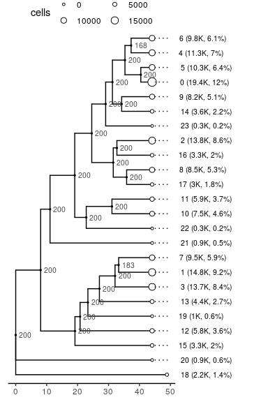

```r
k24_louvain$tree
```

Lets describe the bubbletree:

**bubbles**: The bubbletree has `k=24` bubbles (clusters) shown as leaves. The absolute and relative cell frequencies in each bubble and the bubble IDs are shown as labels. Bubble radii are scaled linearly as the absolute cell count in each bubble, i.e. large bubbles have many cells and small bubbles contain few cells.

We can access the bubble data shown in the bubbletree

```r
knitr::kable(k24_louvain$tree_meta, digits = 2, row.names = F)
```

| label | c | n | p | pct | tree_order |
| --- | --- | --- | --- | --- | --- |
| 6 | 9842 | 161764 | 0.06 | 6.1 | 24 |
| 4 | 11342 | 161764 | 0.07 | 7.0 | 23 |
| 5 | 10274 | 161764 | 0.06 | 6.4 | 22 |
| 0 | 19395 | 161764 | 0.12 | 12.0 | 21 |
| 9 | 8236 | 161764 | 0.05 | 5.1 | 20 |
| 14 | 3615 | 161764 | 0.02 | 2.2 | 19 |
| 23 | 318 | 161764 | 0.00 | 0.2 | 18 |
| 2 | 13837 | 161764 | 0.09 | 8.6 | 17 |
| 16 | 3259 | 161764 | 0.02 | 2.0 | 16 |
| 8 | 8501 | 161764 | 0.05 | 5.3 | 15 |
| 17 | 2987 | 161764 | 0.02 | 1.8 | 14 |
| 11 | 5912 | 161764 | 0.04 | 3.7 | 13 |
| 10 | 7507 | 161764 | 0.05 | 4.6 | 12 |
| 22 | 321 | 161764 | 0.00 | 0.2 | 11 |
| 21 | 889 | 161764 | 0.01 | 0.5 | 10 |
| 7 | 9495 | 161764 | 0.06 | 5.9 | 9 |
| 1 | 14827 | 161764 | 0.09 | 9.2 | 8 |
| 3 | 13657 | 161764 | 0.08 | 8.4 | 7 |
| 13 | 4409 | 161764 | 0.03 | 2.7 | 6 |
| 19 | 1021 | 161764 | 0.01 | 0.6 | 5 |
| 12 | 5772 | 161764 | 0.04 | 3.6 | 4 |
| 15 | 3267 | 161764 | 0.02 | 2.0 | 3 |
| 20 | 895 | 161764 | 0.01 | 0.6 | 2 |
| 18 | 2186 | 161764 | 0.01 | 1.4 | 1 |

**topology**: inter-bubble distances are represented by sums of the corresponding branch lengths in the dendrogram.

Biological interpretation of the different clades and their complex within- clade branching patterns are provided in the following.

### 4. visualization

#### attaching categorical cell features

We will visualize the relative frequencies of categorical cell features including:

- cell type annotations *l1* and *l2*
- donor (sample) IDs

```r
c1 <- meta$celltype.l1
c2 <- gsub(pattern = "Proliferating", replacement = 'prolif.', meta$celltype.l2)
c2 <- gsub(pattern = "CD56bright", replacement = 'CD56', x = c2)
donor <- paste0(meta$donor, '(', meta$time, ')')
```

```r
w0_v <- get_cat_tiles(btd = k24_louvain,
                      f = c1,
                      integrate_vertical = T,
                      round_digits = 0,
                      show_hclust = F,
                      tile_text_size = 2.75,
                      disable_hclust = F,
                      x_axis_name = 'Cell type (l1)')


w0_h <- get_cat_tiles(btd = k24_louvain,
                      f = c1,
                      integrate_vertical = F,
                      round_digits = 0,
                      show_hclust = F,
                      tile_text_size = 2.75,
                      disable_hclust = F,
                      x_axis_name = 'Cell type (l1)')
```

```r
w1_v <- get_cat_tiles(btd = k24_louvain,
                      f = c2,
                      integrate_vertical = T,
                      round_digits = 0,
                      show_hclust = F,
                      tile_text_size = 2.75,
                      disable_hclust = F,
                      x_axis_name = 'Cell type (l2)')

w1_h <- get_cat_tiles(btd = k24_louvain,
                      f = c2,
                      integrate_vertical = F,
                      round_digits = 0,
                      show_hclust = F,
                      tile_text_size = 2.75,
                      disable_hclust = F,
                      x_axis_name = 'Cell type (l2)')
```

```r
w2 <- get_cat_tiles(btd = k24_louvain,
                    f = donor,
                    integrate_vertical = T,
                    round_digits = 0,
                    show_hclust = F,
                    tile_text_size = 2.75,
                    disable_hclust = T,
                    x_axis_name = 'Donor')
```

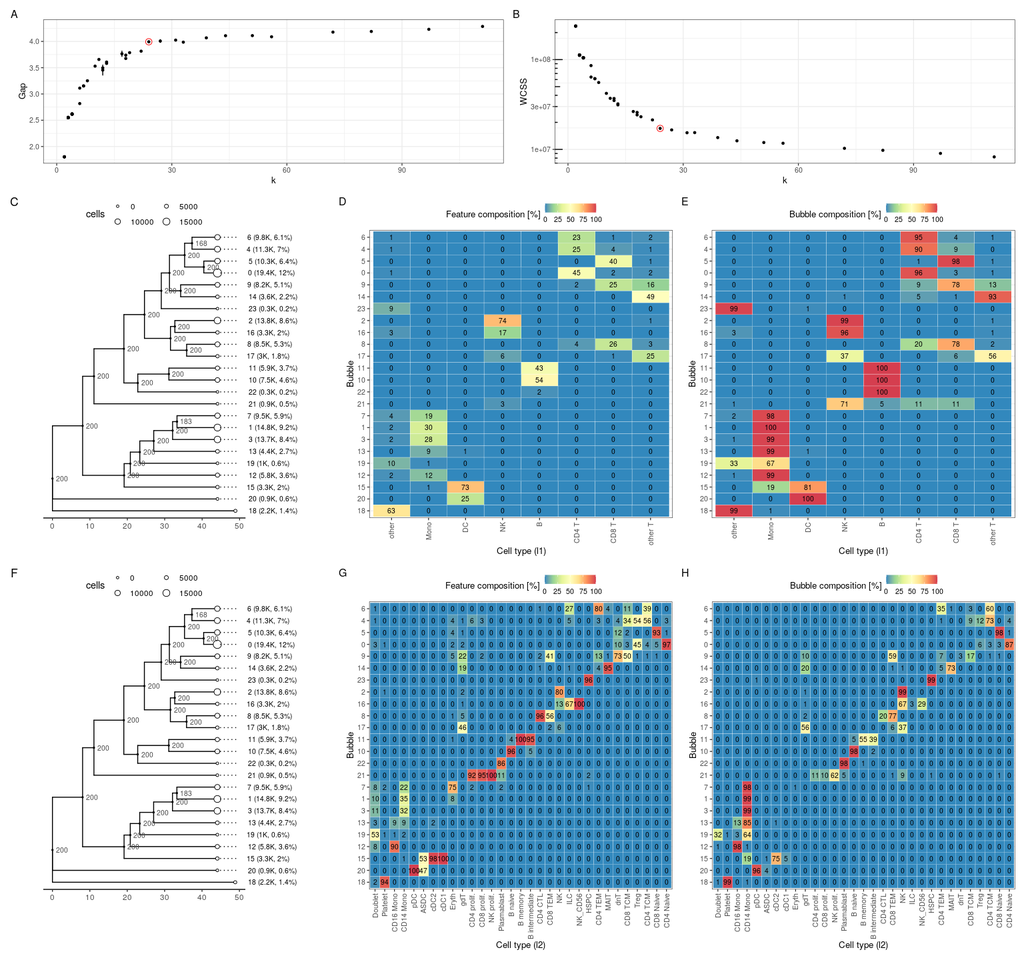

```r
fig_l0 <- g0_r

fig_l1 <- (k24_louvain$tree|w0_v$plot|w0_h$plot)+
  patchwork::plot_layout(widths = c(2, 3, 3))

fig_l2 <- (k24_louvain$tree|w1_v$plot|w1_h$plot)+
  patchwork::plot_layout(widths = c(2, 3, 3))

fig <- (fig_l0/fig_l1/fig_l2)+
  patchwork::plot_annotation(tag_levels = 'A')+
  patchwork::plot_layout(heights = c(1, 2, 2))

rm(fig_l0, fig_l1, fig_l2)
```

#### attaching numeric cell features

Lets visualize the average gene expression of some marker genes in the bubbles:

- GNLY, NKG7: *NK cells*
- IL7R: *CD4 T cells*
- CD8A: *CD8 T cells*
- MS4A1: *B cells*
- CD14, LYZ: *CD14+ Monocytes*
- FCGR3A, MS4A7: *FCGR3A+ Monocytes*
- FCER1A, CST3: *Dendritic Cells*
- PPBP: *Megakaryocytes*

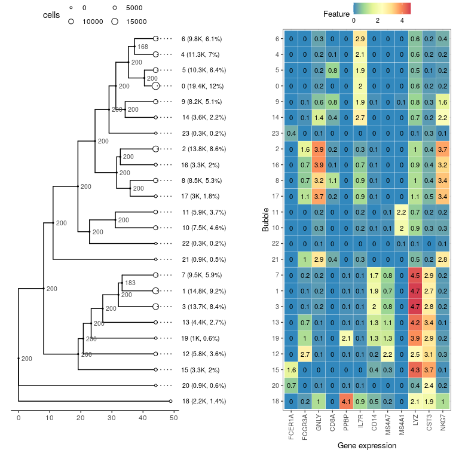

```r
fig_markers <- get_num_tiles(btd = k24_louvain,
                             fs = as,
                             summary_function = "mean",
                             round_digits = 1,
                             show_hclust = F,
                             disable_hclust = T,
                             x_axis_name = "Gene expression",
                             rotate_x_axis_labels = T)

(k24_louvain$tree|fig_markers$plot)+
  patchwork::plot_layout(widths = c(1, 1))
```

Second, we can visualize the distribution of each marker gene in each bubble using violin plots with `get_num_violins`. This function uses the same input as `get_num_tiles`.

Lets invoke this function now.

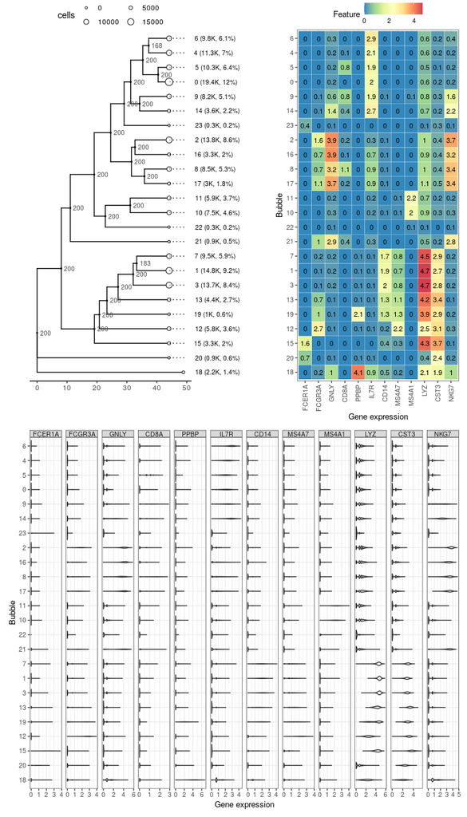

```r
fig_markers_violin <- get_num_violins(btd = k24_louvain,
                      fs = as,
                      x_axis_name = "Gene expression",
                      rotate_x_axis_labels = T)


((k24_louvain$tree|fig_markers$plot)+
    patchwork::plot_layout(widths = c(1, 1)))/
  fig_markers_violin$plot
```

### quality control with `scBubbletree`

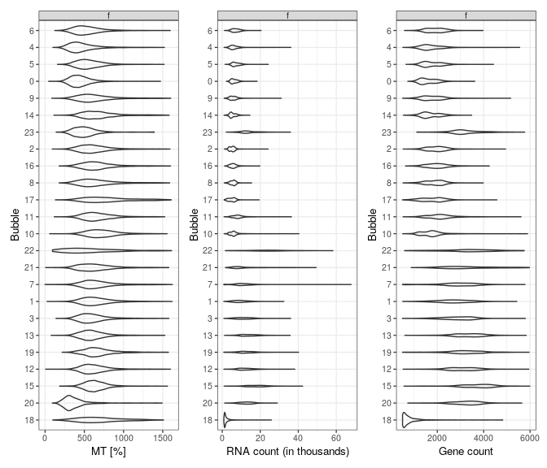

### bubble purity assessment based on Gini impurity index

Can we show quantitatively that by increasing `k` we get “better” clustering in a semi-supervised way? Yes, we can use the Gini impurity index.

Lets invoke the function `get_gini_k` and pass the object `b` obtained earlier together with the cell type predictions:

```r
gini_l1 <- get_gini_k(labels = meta$celltype.l1,
                      obj = b_r)
gini_l2 <- get_gini_k(labels = meta$celltype.l2,
                      obj = b_r)
gini_l3 <- get_gini_k(labels = meta$celltype.l3,
                      obj = b_r)
```

We next plot the Gini scores for the labels at resolution *l1*, *l2* and *l3*.

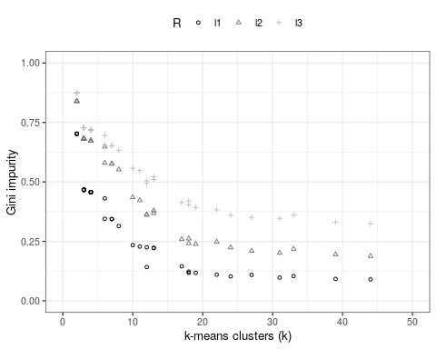

## Are local/global distances between cells preserved by UMAP/t-SNE?

```r
get_euc_dist <- function(x, pairs, m) {

  get_euc <- function(x, y) {
    return(sqrt(sum((x-y)^2)))
  }

  i <- pairs[x,1]
  j <- pairs[x,2]

  return(sqrt(sum((m[i,]-m[j,])^2)))
}


pairs <- t(replicate(n = 5*10^4, sample(x = 1:nrow(A), size = 2)))

i_cell <- meta$celltype.l2[pairs[, 1]]
j_cell <- meta$celltype.l2[pairs[, 2]]
comparison <- ifelse(test = i_cell==j_cell, yes = "w", no = "b")
```

```r
euc_a <- lapply(X = 1:nrow(pairs), pairs = pairs,
                m = A, FUN = get_euc_dist)

euc_u <- lapply(X = 1:nrow(pairs), pairs = pairs,
                m = d@reductions$umap@cell.embeddings[, c("UMAP_1", "UMAP_2")],
                FUN = get_euc_dist)

euc_t <- lapply(X = 1:nrow(pairs), pairs = pairs,
                m = d@reductions$tsne@cell.embeddings[, c("tSNE_1", "tSNE_2")],
                FUN = get_euc_dist)

# memory issue
x <- d@assays$SCT@data[, sort(unique(as.vector(pairs)), decreasing = T)]
x <- as.matrix(x)
x <- t(x)
rownames(x) <- sort(unique(as.vector(pairs)), decreasing = T)
r_x <- rownames(x)
euc_x <- numeric(length = length(euc_a))
for(i in 1:nrow(pairs)) {
  euc_x[i] <- sqrt(sum((x[which(r_x == pairs[i, 1]),]-
                          x[which(r_x == pairs[i, 2]),])^2))

}

dist_preservation <- data.frame(euc_a = unlist(euc_a),
                                euc_u = unlist(euc_u),
                                euc_t = unlist(euc_t),
                                euc_x = unlist(euc_x),
                                i = i_cell,
                                j = j_cell,
                                comparison = comparison)

save(dist_preservation, file = "case_study_B/dist_preservation.RData")
```

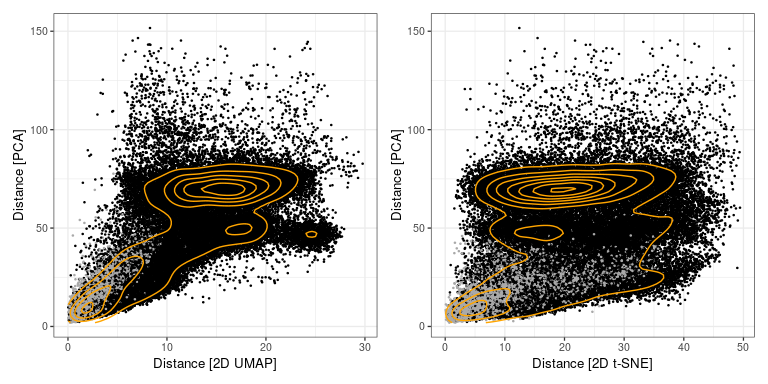

```r
g_pairs_umap_tsne <- ggplot(data = dist_preservation)+
  geom_point(aes(y = euc_a, x = euc_u, col = comparison), size = 0.25)+
  geom_density_2d(aes(y = euc_a, x = euc_u), col = "orange")+
  ylab(label = "Distance [PCA]")+
  xlab(label = "Distance [2D UMAP]")+
  scale_color_manual(values = c("black", "darkgray"))+
  theme(legend.position = "none")|
ggplot(data = dist_preservation)+
  geom_point(aes(y = euc_a, x = euc_t, col = comparison), size = 0.25)+
  geom_density_2d(aes(y = euc_a, x = euc_t), col = "orange")+
  ylab(label = "Distance [PCA]")+
  xlab(label = "Distance [2D t-SNE]")+
  scale_color_manual(values = c("black", "darkgray"))+
  theme(legend.position = "none")

g_pairs_umap_tsne
```

# References

[^1]: Hao, Yuhan, et al. “Integrated analysis of multimodal single-cell data.” Cell 184.13 (2021): 3573-3587.
[^2]: https://satijalab.org/seurat/articles/multimodal_reference_mapping.html
[^3]: https://www.proteinatlas.org/humanproteome/immune+cell